# DATA 202 Homework 6

Sherise Immanuela

2022-12-03

## Problem 1: Setting up the problem

1. Features incldue: building types, roof styles, conditions, etc.
2. Target: Find the sale price of a home
3. This is a regression task because we’re predicting the price of a house sale.
4. One appropriate error metric for this task would be the mean absolute percent error.
5. This task is expected to produce a mean absolute percent error of 10%.
6. An example of an inappropriate error metric is a mean absolute error. The mean absolute error is measured as the average of absolute error values, and it would be inappropriate because the range of values for the data varies widely.

## Problem 2: Fitting and evaluating a model

```r
ames_home_sales <- read_builtin("ames", package = "modeldata") %>%
  mutate(Sale_Price = Sale_Price / 1000) %>%
  filter(Gr_Liv_Area < 4000, Sale_Condition == "Normal")
```

```r
set.seed(456)
ames_split <- initial_split(ames_home_sales, prop = 0.9)
ames_train <- training(ames_split)
ames_test <- testing(ames_split)
```

```r
linear_reg_fit <- fit(linear_reg(mode = "regression"),
  Sale_Price ~ Gr_Liv_Area,
  data = ames_train)
linear_reg_fit
```

```
parsnip model object


Call:
stats::lm(formula = Sale_Price ~ Gr_Liv_Area, data = data)

Coefficients:
(Intercept)  Gr_Liv_Area
    18.4096       0.1061
```

```r
ames_train_predictions <- linear_reg_fit %>%
  augment(ames_train)
```

```r
metrics <- yardstick::metric_set(rsq_trad, mae, mape, rmse)
ames_train_predictions %>%
  metrics(truth = Sale_Price, estimate = .pred) %>%
  select(-.estimator)
```

```
# A tibble: 4 × 2
  .metric  .estimate
  <chr>        <dbl>
1 rsq_trad     0.536
2 mae         33.4
3 mape        20.3
4 rmse        47.7
```

The mean absolute difference between the actual and predicted value (mae) is 33.4, which is about a 20% difference (mape). The percentage is not ideal, but acceptable.

4. The model is expected to predict results with a 20% difference than the actual value.

## Problem 3 (Repeat problem 1)

```r
ames_vs_median <- ames_home_sales %>%
  mutate(sale_category = case_when(
    Sale_Price > median(Sale_Price) ~ "Above Median",
    TRUE ~ "Below Median") %>%
    as_factor() %>%
    fct_relevel("Above Median"))
```

```r
set.seed(123)
ames_vs_median_split <- initial_split(ames_vs_median, prop = 0.9)
ames_vs_median_train <- training(ames_vs_median_split)
ames_vs_median_test <- testing(ames_vs_median_split)
```

```r
model <- decision_tree(mode = "classification") %>%
  fit(sale_category ~ Gr_Liv_Area, data = ames_vs_median_train)
model3
```

```
Error in eval(expr, envir, enclos): object 'model3' not found
```

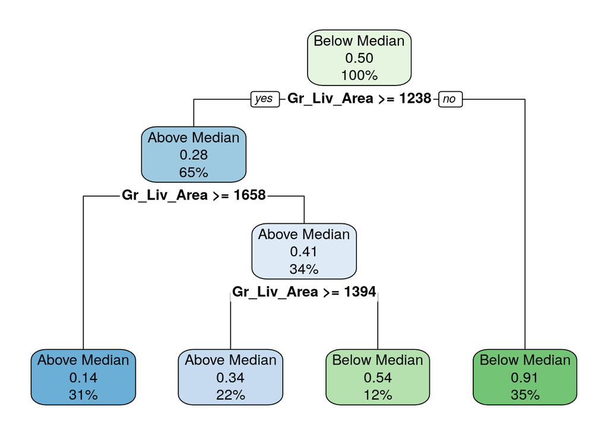

```r
model %>%
  extract_fit_engine() %>%
  rpart.plot::rpart.plot(roundint = FALSE)
```

```r
ames_vs_median_train_predictions <- model %>%
  augment(ames_vs_median_train)
```

## Problem 4 (Repeat problem 2)

```r
levels(ames_vs_median$sale_category)
```

```
[1] "Above Median" "Below Median"
```

```r
metrics <- yardstick::metric_set(accuracy, sensitivity, specificity)
ames_vs_median_train_predictions %>%
  metrics(truth = sale_category, estimate = .pred_class) %>%
  select(-.estimator)
```

```
# A tibble: 3 × 2
  .metric     .estimate
  <chr>           <dbl>
1 accuracy        0.793
2 sensitivity     0.820
3 specificity     0.765
```

The accuracy metric shows that the model was correct 79% of the time. The sensitivity metric shows that the true positive rate of the model is 82%. Given these metrics, the model can generally be accepted to predict whether a home will be sold for above or below the median home sales price.